# Reseasrch Objective

Worldwide, breast cancer is the most common type of cancer in women and the second highest in terms of mortality rates.Diagnosis of breast cancer is performed when an abnormal lump is found (from self-examination or x-ray) or a tiny speck of calcium is seen (on an x-ray). After a suspicious lump is found, the doctor will conduct a diagnosis to determine whether it is cancerous and, if so, whether it has spread to other parts of the body.

The objective is to predict based on diagnostic measurements whether a patient has cancer.In this project, the impact of 5 factors(see in data source) is reviewed on cancer diagnosis(0 or one).

# Research question

1.Predicting diagnosis of breast cancer by using mean_radius, mean_texture, mean_perimeter, mean_area, mean_smoothness factors. 2.Evaluating of accuracy of Decision Tree algorithm for this prediction. Also,Investigating of algorithm improvement by ensembles implementation.

# Data source

The data set was sourced from https://www.kaggle.com/datasets/merishnasuwal/breast-cancer-prediction-dataset. Worldwide, breast cancer is the most common type of cancer in women and the second highest in terms of mortality rates.Diagnosis of breast cancer is performed when an abnormal lump is found (from self-examination or x-ray) or a tiny speck of calcium is seen (on an x-ray). After a suspicious lump is found, the doctor will conduct a diagnosis to determine whether it is cancerous and, if so, whether it has spread to other parts of the body.

This breast cancer dataset was obtained from the University of Wisconsin Hospitals, Madison from Dr. William H. Wolberg. Dataset for AI for Social Good: Women Coders' Bootcamp organized by Artificial Intelligence for Development in collaboration with UNDP Nepal'. Factors in this data set is: mean_radius,mean_texture, mean_perimeter, mean_area, mean_smoothness.

diagnosis: The diagnosis of breast tissues (1 = malignant, 0 = benign) where malignant denotes that the disease is harmful

mean_radius: mean of distances from center to points on the perimeter

mean_texture: standard deviation of gray-scale values

mean_perimeter: mean size of the core tumor

mean_area: mean area of the core tumor

mean_smoothness: mean of local variation in radius lengths

# Analyze data by descriptive statistics and graphical visualization.

```python
# Import the following packages

import numpy as np
import pandas as pd
from sklearn.model_selection import train_test_split
from sklearn.naive_bayes import GaussianNB
from sklearn.metrics import accuracy_score
import matplotlib.pyplot as plt
import seaborn as sns
from sklearn.datasets import load_iris
from sklearn.model_selection import train_test_split
from sklearn.naive_bayes import GaussianNB
from sklearn.model_selection import KFold
from sklearn.model_selection import cross_validate
from sklearn.metrics import classification_report, confusion_matrix
```

```python
import warnings
warnings.filterwarnings('ignore')

BreastCancerData = pd.read_csv('Breast_cancer_data.csv')
print(BreastCancerData.shape)
print(BreastCancerData.head())
```

```
(569, 6)
   mean_radius  mean_texture  mean_perimeter  mean_area  mean_smoothness  \
0        17.99         10.38          122.80     1001.0          0.11840
1        20.57         17.77          132.90     1326.0          0.08474
2        19.69         21.25          130.00     1203.0          0.10960
3        11.42         20.38           77.58      386.1          0.14250
4        20.29         14.34          135.10     1297.0          0.10030

   diagnosis
0          0
1          0
2          0
3          0
4          0
```

```python
# Print the summary of the data

print(BreastCancerData.describe())
print(BreastCancerData.describe().T)
```

```
       mean_radius  mean_texture  mean_perimeter    mean_area  \
count   569.000000    569.000000      569.000000   569.000000
mean     14.127292     19.289649       91.969033   654.889104
std       3.524049      4.301036       24.298981   351.914129
min       6.981000      9.710000       43.790000   143.500000
25%      11.700000     16.170000       75.170000   420.300000
50%      13.370000     18.840000       86.240000   551.100000
75%      15.780000     21.800000      104.100000   782.700000
max      28.110000     39.280000      188.500000  2501.000000

       mean_smoothness   diagnosis
count       569.000000  569.000000
mean          0.096360    0.627417
std           0.014064    0.483918
min           0.052630    0.000000
25%           0.086370    0.000000
50%           0.095870    1.000000
75%           0.105300    1.000000
max           0.163400    1.000000
                 count        mean         std        min        25%  \
mean_radius      569.0   14.127292    3.524049    6.98100   11.70000
mean_texture     569.0   19.289649    4.301036    9.71000   16.17000
mean_perimeter   569.0   91.969033   24.298981   43.79000   75.17000
mean_area        569.0  654.889104  351.914129  143.50000  420.30000
mean_smoothness  569.0    0.096360    0.014064    0.05263    0.08637
diagnosis        569.0    0.627417    0.483918    0.00000    0.00000

                       50%       75%        max
mean_radius       13.37000   15.7800    28.1100
mean_texture      18.84000   21.8000    39.2800
mean_perimeter    86.24000  104.1000   188.5000
mean_area        551.10000  782.7000  2501.0000
mean_smoothness    0.09587    0.1053     0.1634
diagnosis          1.00000    1.0000     1.0000
```

```python
# Print the datatypes which are keys.
types = BreastCancerData.dtypes
print(types)
print("Keys of Breast Cancer dataset:\n", BreastCancerData.keys())
```

```
mean_radius        float64
mean_texture       float64
mean_perimeter     float64
mean_area          float64
mean_smoothness    float64
diagnosis            int64
dtype: object
Keys of Breast Cancer dataset:
 Index(['mean_radius', 'mean_texture', 'mean_perimeter', 'mean_area',
       'mean_smoothness', 'diagnosis'],
      dtype='object')
```

```python
# print the target variable

print("diagnosis:", BreastCancerData['diagnosis'])
```

```
diagnosis: 0      0
1      0
2      0
3      0
4      0
      ..
564    0
565    0
566    0
567    0
568    1
Name: diagnosis, Length: 569, dtype: int64
```

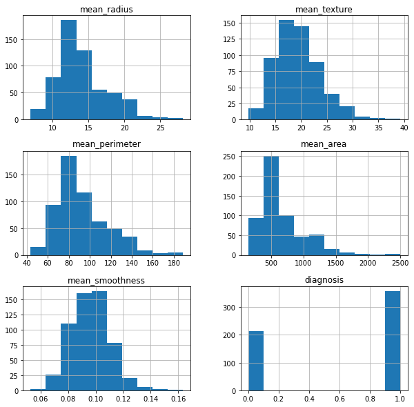

```python
# Create the histogram of all the variables. Set Figure size 10 by 10 inches

%matplotlib inline
BreastCancerData.hist(figsize = (10,10))
plt.show()
```

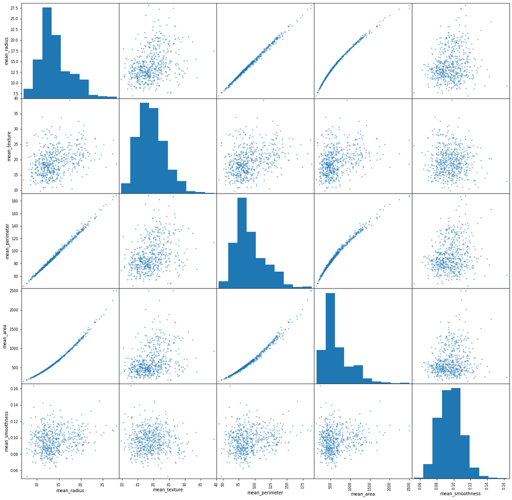

```python
# create a grid of scatterplot and histogram

%matplotlib inline
X = BreastCancerData[['mean_radius', 'mean_texture', 'mean_perimeter', 'mean_area','mean_smoothness']]
from pandas.plotting import scatter_matrix
scatter_matrix(X,figsize=(20,20))
plt.show()
```

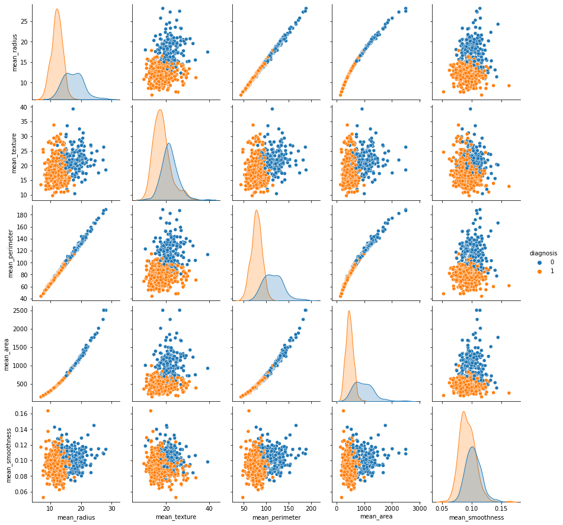

```python
# Creating a pairplot differentiatied by diagnosis

%matplotlib inline
X = BreastCancerData[['mean_radius', 'mean_texture', 'mean_perimeter', 'mean_area','mean_smoothness','diagnosis']]
from pandas.plotting import scatter_matrix
sns.pairplot(X, hue = 'diagnosis')
plt.show()
```

# Algorithm Implementation

### Prepare data by using relevant preprocessing transformations, data standardization,deaing with null.

```python
import numpy as np
import matplotlib.pyplot as plt
import pandas as pd
from sklearn import metrics
from sklearn.preprocessing import StandardScaler
import matplotlib.pyplot as plt
import warnings
warnings.filterwarnings('ignore')


# Divide data into predictor features vector and the label of the target variable 'diagnosis'

X = BreastCancerData[['mean_radius', 'mean_texture', 'mean_perimeter', 'mean_area','mean_smoothness']]
y = BreastCancerData[['diagnosis']]

# Check if null values in the columns
X.isna().sum()
```

```
mean_radius        0
mean_texture       0
mean_perimeter     0
mean_area          0
mean_smoothness    0
dtype: int64
```

### Data Preparation

```python
# Divide data into predictor features vector and the label of the trget variable 'diagnosis'

BreastCancerData = pd.read_csv('Breast_cancer_data.csv')
X = pd.DataFrame(BreastCancerData)
X = X.iloc[:,0:5]
y = BreastCancerData['diagnosis']
#print(X)
#print(y)

# Dividing data into two subsets :train and test set.Training set trains the model

from sklearn.model_selection import train_test_split
X_train, X_test, y_train, y_test = train_test_split(X, y, test_size=0.20)

# Data normalization

from sklearn.preprocessing import StandardScaler
scaler = StandardScaler()
scaler.fit(X_train)

X_train = scaler.transform(X_train)
X_test = scaler.transform(X_test)
```

### Train Data and Testing the data using Decision Tree . And Evaluate

```python
# https://scikit-learn.org/stable/modules/generated/sklearn.tree.DecisionTreeClassifier.html

from sklearn.tree import DecisionTreeClassifier

# Creating an instance of the Decision Tree
tree = DecisionTreeClassifier(random_state=0)
# Fiting the training data to the model
tree.fit(X_train, y_train)
# Printing the training accuracy with 3 significant figure accuracy
print("Accuracy on training set: {:.3f}".format(tree.score(X_train, y_train)))
# Printing the testing accuracy with 3 significant figure accuracy
print("Accuracy on test set: {:.3f}".format(tree.score(X_test, y_test)))
```

```
Accuracy on training set: 1.000
Accuracy on test set: 0.912
```

```python
# Improving the Decision Tree accuracy by specifying the max_ depth.
tree = DecisionTreeClassifier(max_depth=4, random_state=0)
tree.fit(X_train, y_train)

print("Accuracy on training set: {:.3f}".format(tree.score(X_train, y_train)))
print("Accuracy on test set: {:.3f}".format(tree.score(X_test, y_test)))
```

```
Accuracy on training set: 0.947
Accuracy on test set: 0.947
```

```python
print("Feature importances:")
print(tree.feature_importances_)
```

```
Feature importances:
[0.0315027  0.10862077 0.76833981 0.         0.09153673]
```

## Feature Importance and techniques to improve performance

```
5
```

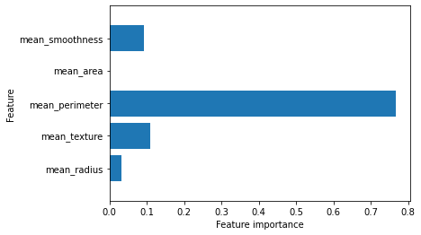

```python
# Creating a function to generate feature importance and plot it.

def plot_feature_importances_CancerData(model):
# extractibg the number of predictive feature variables(columns)
    n_features = X.shape[1]
    print(n_features)
    plt.barh(np.arange(n_features), model.feature_importances_, align='center')
    plt.yticks(np.arange(n_features), X)
    plt.xlabel("Feature importance")
    plt.ylabel("Feature")
    plt.ylim(-1, n_features)

# Calling the function to extract feature importance and passing the model named tree (constructed earlier) into it.

plot_feature_importances_CancerData(tree)
```

# Ensemble Implementation Techniques

## Random Forest

```python
# https://scikit-learn.org/stable/modules/generated/sklearn.ensemble.RandomForestClassifier.html

from sklearn.ensemble import RandomForestClassifier
from sklearn.datasets import make_moons

# StratifiedKFold is a variation of k-fold which returns stratified folds: each set
# contains approximately the same percentage of samples of each target class as the complete set.

X_train, X_test, y_train, y_test = train_test_split(X, y, stratify=y,
                                                    random_state=42)
# number of trees =100, maximum depth = 5
forest = RandomForestClassifier(max_depth=5,n_estimators=100, random_state=2)
forest.fit(X_train, y_train)
print("Accuracy on training set: {:.3f}".format(forest.score(X_train, y_train)))
print("Accuracy on test set: {:.3f}".format(forest.score(X_test, y_test)))
```

```
Accuracy on training set: 0.981
Accuracy on test set: 0.930
```

```
Accuracy on training set: 1.000
Accuracy on test set: 0.923
5
```

[figure not shown]

```python
forest = RandomForestClassifier(n_estimators=100, random_state=0)
forest.fit(X_train, y_train)

print("Accuracy on training set: {:.3f}".format(forest.score(X_train, y_train)))
print("Accuracy on test set: {:.3f}".format(forest.score(X_test, y_test)))

# Calling the function to extract feature importance and passing the model named forest (constructed earlier) into it.
plot_feature_importances_DiabetData(forest)
```

# Comparing Algorithms

```python
import warnings
warnings.filterwarnings("ignore")

from sklearn.ensemble import RandomForestClassifier
from sklearn.tree import DecisionTreeClassifier
from sklearn.model_selection import train_test_split
from sklearn.naive_bayes import GaussianNB
from sklearn.metrics import accuracy_score
from sklearn.model_selection import train_test_split
from sklearn.naive_bayes import GaussianNB
from sklearn.model_selection import cross_validate
from sklearn.metrics import classification_report, confusion_matrix
from sklearn.model_selection import cross_val_score,KFold
from sklearn.preprocessing import LabelEncoder
from sklearn.neighbors import KNeighborsClassifier
from sklearn.neural_network import MLPClassifier

# Algorithms
models = []
models.append(( 'Naive Bayes' , GaussianNB()))
models.append(( 'KNN' , KNeighborsClassifier()))
models.append(( 'RandomForestClassifier' , RandomForestClassifier()))

# Test options and evaluation metric
seed = 347288723
print('Diabet data set:\n')
# Create a list save results
results = []
# Create a list ot save model names
names = []
for name, model in models:
# create a kfold cross fold validation with 10 splits
  models_kfold = KFold(n_splits=10, random_state=seed, shuffle=True)
 # passing each model into the cross validation for training
  cv_results = cross_val_score(model, X_train, np.ravel(y_train), cv=models_kfold)
 # passing each model into the cross validation for testing
  cv_results_testing = cross_val_score(model, X_test, np.ravel(y_test), cv=models_kfold)
 # Save the results
  results.append(cv_results)
 # Save the names
  names.append(name)
 # Print the results
  msg = "Training accuracy %s: %f %%" % (name, cv_results.mean()*100)
  print(msg)
  msg_testing = "Testing accuracy %s: %f %%" % (name, cv_results_testing.mean()*100)
  print(msg_testing)
print('10-Fold cross-validation accuracy score applied for the training data for 3 classifiers')
```

```
Diabet data set:

Training accuracy Naive Bayes: 90.847176 %
Testing accuracy Naive Bayes: 88.809524 %
Training accuracy KNN: 86.871539 %
Testing accuracy KNN: 83.904762 %
Training accuracy RandomForestClassifier: 90.858250 %
Testing accuracy RandomForestClassifier: 88.095238 %
10-Fold cross-validation accuracy score applied for the training data for 3 classifiers
```

## Creating a Confusion Matrix

```
Accuracy on  RandomForest Classifier test data: 93.01 %
Confusion Matrix
 [[49  4]
 [ 6 84]]
```

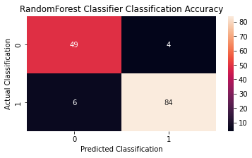

```python
# Creating a confusion Matrix
rfc_model = RandomForestClassifier(n_estimators=120, bootstrap= True, n_jobs=-1, oob_score= True)
rfc_model.fit(X_train, y_train)
y_predicted_rfc = rfc_model.predict(X_test)
print("Accuracy on  RandomForest Classifier test data: {:.2f} %".format(rfc_model.score(X_test, y_test)*100))
cm = confusion_matrix(y_test, y_predicted_rfc)
print("Confusion Matrix \n",cm)
plt.figure(figsize=(6, 3))
sns.heatmap(cm, annot=True)
plt.xlabel('Predicted Classification')
plt.ylabel('Actual Classification')
plt.title('RandomForest Classifier Classification Accuracy')
plt.show()
```

# Conclusion

In this project we have explored breast cancer diagnosis (0 means no diagnosis, 1 means yes diagnosis) with some factors: mean_radius, mean_texture, mean_perimeter, mean_area, mean_smoothness. The research used Decision Tree algorithm model on dataset, to identify what outcome was predicted (0 means no diagnosis, 1 means yes diagnosis). I found its accuracy. In this search, by improvement performance with Random Forest, I found its effect. And finally, I compared some algorithms together.

Also, I found best features.

First, I modeled my data with Decision Tree algorithm. I found high accuracy (test accuracy=91%). Also, I found my model has overfitting. For improvement, I decrease the depth of tree(max_depth=4). So, accuracy became very well (train accuracy=94%, test accuracy=94%). We can see the overfitting problem is solved relatively. Also, the best feature is mean_perimeter.

And finally, I compared 3 algorithms (K-nn, Naive Baye’s, Random Forest) with cv=10. I found test accuracy in Random Forest and naïve Bay’s algorithms are better than the K-nn algorithm. The accuracy of (Random Forest and naïve Bay’s algorithms) both testing and training data are very close together. Also, cross validation was not very effective because the model didn’t have high overfitting problem.

Now with Random Forest model, we can predict with 93% accuracy whether a patient with certain data we have has breast cancer diagnosis or not. Also, we can predict with Decision tree algorithm (with max_depth=4) with 94% accuracy. These models work well for my data. As we can see in data visualization above, some predictor features in this data set are very correlated together. Decision trees are by nature immune to multi-collinearity. So, I had very good accuracy with decision tree and Random forest with this data set.

# Refrences

1. https://scikit-learn.org/stable/modules/generated/sklearn.tree.DecisionTreeClassifier.html
2. https://www.kaggle.com/datasets/merishnasuwal/breast-cancer-prediction-dataset